# Explore_bikeshare_data

### Explore Bike Share Data

For this project, your goal is to ask and answer three questions about the available bikeshare data from Washington, Chicago, and New York. This notebook can be submitted directly through the workspace when you are confident in your results.

You will be graded against the project [Rubric](https://review.udacity.com/#!/rubrics/2508/view) by a mentor after you have submitted. To get you started, you can use the template below, but feel free to be creative in your solutions!

```r
library(ggplot2)
#name datasets
ny = read.csv('new_york_city.csv')
wash = read.csv('washington.csv')
chi = read.csv('chicago.csv')
```

### Question 1

**What is the age of bikeshare users by gender in Chicago and New York City?.**

1. 54770

2. 9

1. 8630

2. 9

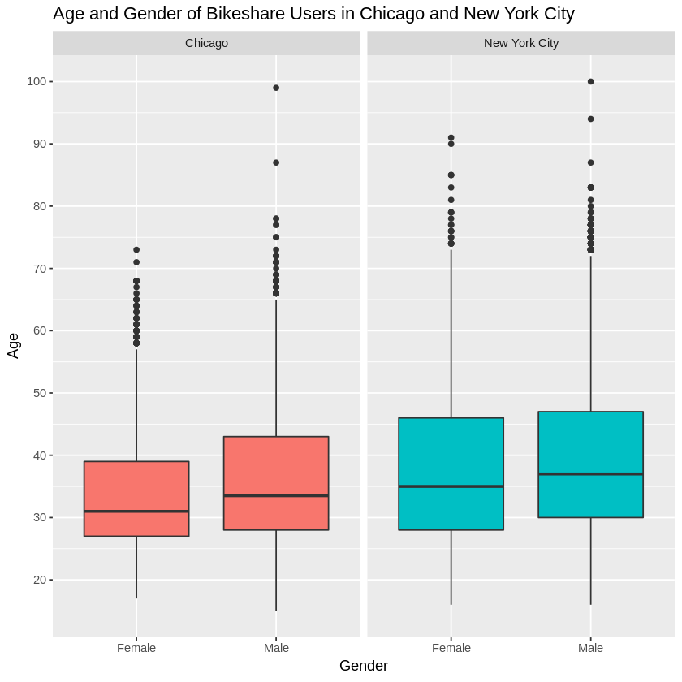

```r
#QUESTION 1 - What is the age of bikeshare users by gender in Chicago and New York City?
#Load packages
library(ggplot2)

#Load Datafiles for each Citys Bike Data
chi<- read.csv("chicago.csv", sep = ",")
ny<- read.csv("new_york_city.csv", sep = ",")

#Check number of rows per dataset
dim(ny)
dim(chi)

#add cityname column to CHI and NYC data
ny<-cbind(c(rep("New York City", times=54770)), ny)
colnames(ny)[1] <- "City"

chi<-cbind(c(rep("Chicago", times=8630)), chi)
colnames(chi)[1] <- "City"

#Compbine NYC and CHI data
multi<-rbind(chi, ny)

#Create a new column with age (based on dataset year of 2017)
multi$Age <- (2017-multi$Birth.Year)

#Remove blanks in gender data
multi<-multi[!(multi$Gender== ""), ]

#Box plot of user age by gender. Removed users over 100 yrs age and under 15 (not likely users)
ggplot(aes(x = Gender, y = Age), data = multi)  +
  geom_boxplot(aes(fill = as.factor(City)), show.legend = FALSE) +
  scale_y_continuous(breaks = seq(10,100, 10), lim = c(15, 100)) +
  facet_wrap(~City) +
  labs(title="Age and Gender of Bikeshare Users in Chicago and New York City")
```

```r
#Symmary Stats
by(multi$Age, multi$City, summary)
```

```
multi$City: Chicago
   Min. 1st Qu.  Median    Mean 3rd Qu.    Max.
   15.0    28.0    33.0    36.1    42.0   118.0
------------------------------------------------------------
multi$City: New York City
   Min. 1st Qu.  Median    Mean 3rd Qu.    Max.    NA's
  16.00   29.00   36.00   38.78   47.00  131.00       1
```

```r
by(multi$Age, multi$Gender, summary)
```

```
multi$Gender:
NULL
------------------------------------------------------------
multi$Gender: Female
   Min. 1st Qu.  Median    Mean 3rd Qu.    Max.    NA's
   16.0    28.0    34.0    37.4    46.0   124.0       1
------------------------------------------------------------
multi$Gender: Male
   Min. 1st Qu.  Median    Mean 3rd Qu.    Max.
   15.0    29.0    36.0    38.8    47.0   131.0
```

**When we look at the age of bikeshare users, Chicago had younger riders compared to NYC (Median age 33 compared to 36). New York City had a wider age range of users with the inner quartile spreading 18 years compared to an inner quartile spread of 14 years in Chicago. The median age of female riders (34 years) was younger than male riders (36 years).**

### Question 2

**What months are the bikes used most in each city?.**

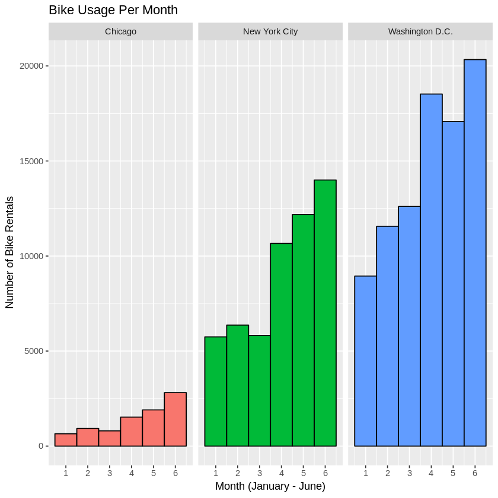

```r
#QUESTION 2 - What months are the bikes used most?
#Load packages
library(ggplot2)
library(lubridate)

#Load Datafiles for each Citys Bike Data
chi<- read.csv("chicago.csv", sep = ",")
ny<- read.csv("new_york_city.csv", sep = ",")
wash<-read.csv("washington.csv", sep = ",")

#add cityname column to Chicago, Washington and NYC data
ny<-cbind(c(rep("New York City", times=54770)), ny[,1:7])
colnames(ny)[1] <- "City"

chi<-cbind(c(rep("Chicago", times=8630)), chi[,1:7])
colnames(chi)[1] <- "City"

wash<-cbind(c(rep("Washington D.C.", times=89051)), wash)
colnames(wash)[1] <- "City"

##Compbine NYC, Wash and Chi data
multi<-rbind(chi, ny, wash)

##Pull out Month from rental start.time. Call it bike.month
bike.month <-month(as.POSIXct(multi$Start.Time, format = "%Y-%m-%d %H:%M:%S"))
multi<-cbind(multi, bike.month)

##Graph
ggplot(aes(x=bike.month), data= multi) +
  geom_histogram(aes(fill = as.factor(City)), show.legend = FALSE, binwidth=1, color = "black") +
  ggtitle('Bike Usage Per Month') +
  scale_x_continuous(breaks = seq(1, 6, 1)) +
  labs(x = "Month (January - June)", y = "Number of Bike Rentals") +
  facet_wrap(~City)
```

```r
by(multi$bike.month, multi$City, summary)
```

[output not shown]

```r
summary(multi$City)
```

**Chicago**

8630

**New York City**

54770

**Washington D.C.**

89051

**We see some interesting trends comparing bike users by month in each city. Over all, Washington D.C. has the most users (89051) compared to NYC (54770) and Chicago (8630). Perhaps this is due to a milder climate or perhaps the bike is a more efficient method of transportation in Washington D.C. and NYC. There was also a significant increasing trend of bike rentals in all cities in warmer months (May and June). In NYC and Washington D.C., the median bike usage fell in April. In Chicago, the median bike usage landed in May.**

### Question 3

**How does trip duration differ between customers and subscribers?**

[figure not shown]

```r
#QUESTION 3 - How does trip duration vary between customers and subscribers?
#Load packages
library(ggplot2)

#Load Datafiles for each Citys Bike Data
chi<- read.csv("chicago.csv", sep = ",")
ny<- read.csv("new_york_city.csv", sep = ",")
wash<-read.csv("washington.csv", sep = ",")

#add cityname column to Chicago, Washington and NYC data
ny<-cbind(c(rep("New York City", times=54770)), ny[,1:7])
colnames(ny)[1] <- "City"

chi<-cbind(c(rep("Chicago", times=8630)), chi[,1:7])
colnames(chi)[1] <- "City"

wash<-cbind(c(rep("Washington D.C.", times=89051)), wash)
colnames(wash)[1] <- "City"

##Compbine NYC, Wash and Chi data
multi<-rbind(chi, ny, wash)

#Remove blanks in user.type data
multi<-multi[!(multi$User.Type== ""), ]

##Graph trip duration by user type. Only showing trip length < 1 hour.
ggplot(aes(x = User.Type, y=Trip.Duration), data = multi) +
    coord_cartesian(ylim =c(0, 3600)) +
    geom_boxplot(aes(fill = as.factor(City)), show.legend = FALSE) +
    labs(title = "Trip Durations of Customers and Subscribers", x = "", y = "Trip Duration (Minutes)") +
    facet_wrap(~City)
```

```r
by(multi$Trip.Duration, multi$User.Type, summary)
```

```
multi$User.Type:
NULL
------------------------------------------------------------
multi$User.Type: Customer
     Min.   1st Qu.    Median      Mean   3rd Qu.      Max.
     61.3     915.4    1450.0    2514.7    2404.5 1088634.0
------------------------------------------------------------
multi$User.Type: Subscriber
    Min.  1st Qu.   Median     Mean  3rd Qu.     Max.
    60.0    352.2    567.5    739.5    914.7 170032.9
```

```r
by(multi$Trip.Duration, multi$City, summary)
```

```
multi$City: Chicago
   Min. 1st Qu.  Median    Mean 3rd Qu.    Max.
   60.0   394.0   670.0   936.9  1119.0 85408.0
------------------------------------------------------------
multi$City: New York City
     Min.   1st Qu.    Median      Mean   3rd Qu.      Max.
     61.0     368.0     609.0     901.6    1049.0 1088634.0
------------------------------------------------------------
multi$City: Washington D.C.
    Min.  1st Qu.   Median     Mean  3rd Qu.     Max.
    60.3    410.9    707.0   1234.0   1233.2 904591.4
```

## Finishing Up

> Congratulations! You have reached the end of the Explore Bikeshare Data Project. You should be very proud of all you have accomplished!

> **Tip**: Once you are satisfied with your work here, check over your report to make sure that it is satisfies all the areas of the [rubric](https://review.udacity.com/#!/rubrics/2508/view).

## Directions to Submit

> Before you submit your project, you need to create a .html or .pdf version of this notebook in the workspace here. To do that, run the code cell below. If it worked correctly, you should get a return code of 0, and you should see the generated .html file in the workspace directory (click on the orange Jupyter icon in the upper left).

> Alternatively, you can download this report as .html via the **File** > **Download as** submenu, and then manually upload it into the workspace directory by clicking on the orange Jupyter icon in the upper left, then using the Upload button.

> Once you've done this, you can submit your project by clicking on the "Submit Project" button in the lower right here. This will create and submit a zip file with this .ipynb doc and the .html or .pdf version you created. Congratulations!

```r
system('python -m nbconvert Explore_bikeshare_data.ipynb')
```